# DS606-Lab7

George Cruz

2020-10-18

#Inference for Numerical Data

```r
library(tidyverse)
library(openintro)
library(infer)
data(yrbss)
```

### Exercise 1

**What are the cases in this data set? How many cases are there in our sample?** Individual Youth behavior. There are 13,583 cases in our sample. Each case represents an individual student’s behavior and demographic info.

```r
glimpse(yrbss)
```

```
## Rows: 13,583
## Columns: 13
## $ age                      <int> 14, 14, 15, 15, 15, 15, 15, 14, 15, 15, 15...
## $ gender                   <chr> "female", "female", "female", "female", "f...
## $ grade                    <chr> "9", "9", "9", "9", "9", "9", "9", "9", "9...
## $ hispanic                 <chr> "not", "not", "hispanic", "not", "not", "n...
## $ race                     <chr> "Black or African American", "Black or Afr...
## $ height                   <dbl> NA, NA, 1.73, 1.60, 1.50, 1.57, 1.65, 1.88...
## $ weight                   <dbl> NA, NA, 84.37, 55.79, 46.72, 67.13, 131.54...
## $ helmet_12m               <chr> "never", "never", "never", "never", "did n...
## $ text_while_driving_30d   <chr> "0", NA, "30", "0", "did not drive", "did ...
## $ physically_active_7d     <int> 4, 2, 7, 0, 2, 1, 4, 4, 5, 0, 0, 0, 4, 7, ...
## $ hours_tv_per_school_day  <chr> "5+", "5+", "5+", "2", "3", "5+", "5+", "5...
## $ strength_training_7d     <int> 0, 0, 0, 0, 1, 0, 2, 0, 3, 0, 3, 0, 0, 7, ...
## $ school_night_hours_sleep <chr> "8", "6", "<5", "6", "9", "8", "9", "6", "...
```

```r
summary(yrbss$weight)
```

```
##    Min. 1st Qu.  Median    Mean 3rd Qu.    Max.    NA's
##   29.94   56.25   64.41   67.91   76.20  180.99    1004
```

### Exercise 2

**How many observations are we missing weights from?** We’re missing 1,004.

```r
yrbss <- yrbss %>%
  mutate(physical_3plus = ifelse(yrbss$physically_active_7d > 2, "yes", "no"))
```

### Excercise 3

**Make a side-by-side boxplot of physical_3plus and weight. Is there a relationship between these two variables? What did you expect and why?**

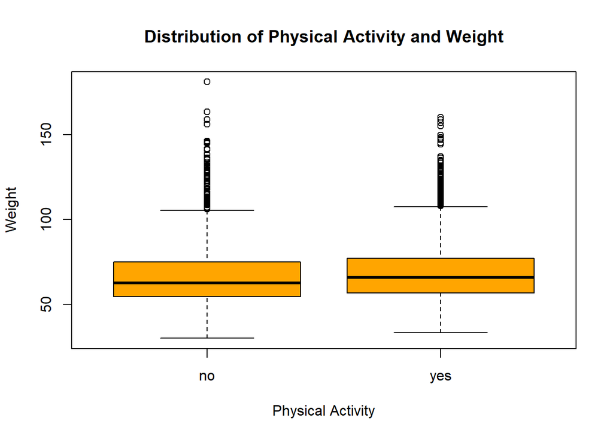

```r
boxplot(yrbss$weight ~ yrbss$physical_3plus, col="orange", main="Distribution of Physical Activity and Weight", ylab="Weight", xlab="Physical Activity")
```

There appears to be minimal change based on the physical activity. The mean weight of the “yes” is slightly higher than the “no” and it appears to be a more normalized distribution. I expected the mean weight of the “no” to be higher based on the physical activity.

```r
yrbss %>%
  group_by(physical_3plus) %>%
  summarise(mean_weight = mean(weight, na.rm = TRUE))
```

```
## # A tibble: 3 x 2
##   physical_3plus mean_weight
##   <chr>                <dbl>
## 1 no                    66.7
## 2 yes                   68.4
## 3 <NA>                  69.9
```

###Exercise 4 The conditions we need for inference on one proportion are: Random: The data comes from a random or randomized experiment. Normal: The sampling distribution of p^ needs to be approximately normal — needs at least 10 expected successes and 10 expected failures. Independent: Individual observations need to be independent.

###Exercise 5 H0: There’s no statistical difference in weight due to exercise. H1: The average weights are different between those who exercise at least 3 times a week.

```r
obs_diff <- yrbss %>%
  specify(weight ~ physical_3plus) %>%
  calculate(stat = "diff in means", order = c("yes", "no"))
null_dist <- yrbss %>%
  specify(weight ~ physical_3plus) %>%
  hypothesize(null = "independence") %>%
  generate(reps = 1000, type = "permute") %>%
  calculate(stat = "diff in means", order = c("yes", "no"))
```

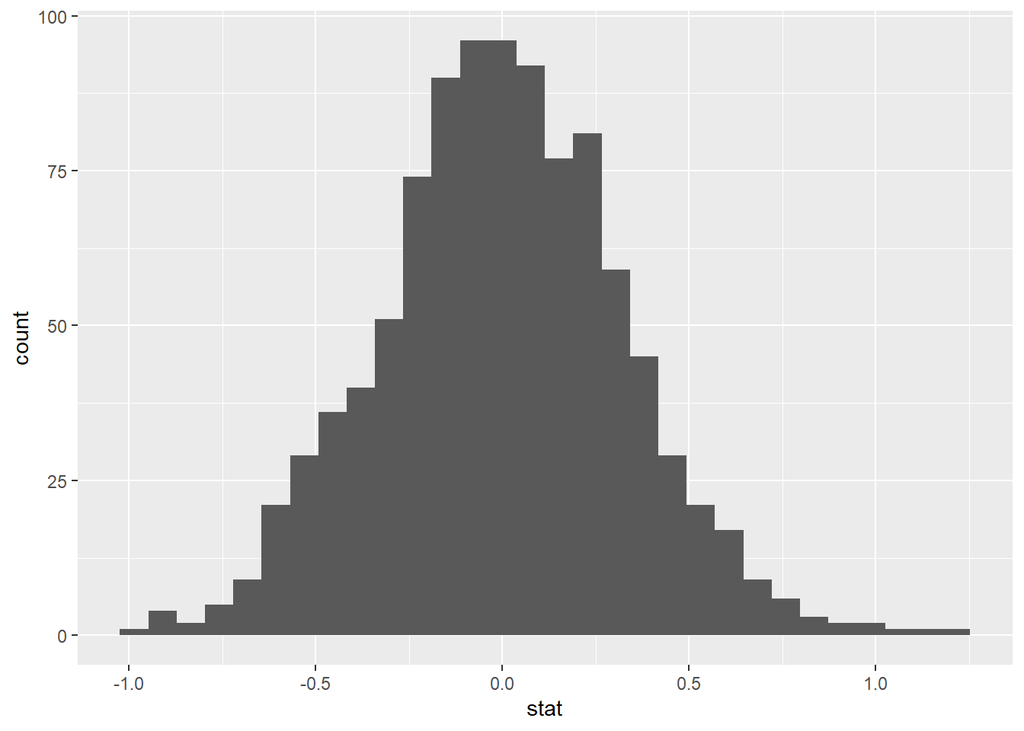

```r
ggplot(data = null_dist, aes(x = stat)) +
  geom_histogram()
```

### Exercise 6

```r
null_dist %>%
  filter(stat >= obs_diff)
```

```
## # A tibble: 0 x 2
## # ... with 2 variables: replicate <int>, stat <dbl>
```

We found no permutation with a difference with at least obs_stat.

```r
null_dist %>%
  get_p_value(obs_stat = obs_diff, direction = "two_sided")
```

```
## Warning: Please be cautious in reporting a p-value of 0. This result is an
## approximation based on the number of `reps` chosen in the `generate()` step. See
## `?get_p_value()` for more information.
```

```
## # A tibble: 1 x 1
##   p_value
##     <dbl>
## 1       0
```

What this warning means is that, although the result in calculations is 0, p-value is an *approximation* and not the real zero. As the number of repetitions grow, the p-value becomes increasingly small or approaches 0.

### Exercise 7

```r
p1 <- yrbss %>%
    filter(physical_3plus == "yes") %>%
    summarise(mean_weight = mean(weight, na.rm = TRUE),
              total = n())
p2 <- yrbss %>%
  filter(physical_3plus == "no") %>%
    summarise(mean_weight = mean(weight, na.rm = TRUE),
              total = n())

n <- 13583 - 1004

prop1 <- p1$total/n
prop2 <- p2$total/n

mean_diff <- p1$mean_weight - p2$mean_weight

se <- ( ((prop1 * (1 - prop1)) / n) +  ((prop2 * (1 - prop2)) / n)) ** 0.5
z <- 1.96

me <-z * se

ci_95 <- c(mean_diff - me, mean_diff + me)

ci_95
```

```
## [1] 1.763068 1.786101
```

The 95% confidence interval of the difference between those who exercise regularly and those who do not is between 1.76 and 1.79kg. This means that there is a difference between those who exercise and those who do not and we should reject the null hypothesis.

### Exercise 8

```r
z = 1.96
mean_height <- mean(yrbss$height, na.rm = TRUE)
sd_height <- sd(yrbss$height, na.rm = TRUE)
total_height <- yrbss %>%
  filter(!is.na(height)) %>%
  summarise(n = n())

total_height <- total_height$n

ci_low <- mean_height - (z * (sd_height/sqrt(total_height)))
ci_high <- mean_height + (z * (sd_height/sqrt(total_height)))

ci_95 <- c(ci_low, ci_high)
ci_95
```

```
## [1] 1.689411 1.693071
```

The 95% confidence interval is between 1.6894 and 1.6930

### Exercise 9

```r
z = 1.64
#mean_height <- mean(yrbss$height, na.rm = TRUE)
#sd_height <- sd(yrbss$height, na.rm = TRUE)
#total_height <- yrbss %>%
#  filter(!is.na(height)) %>%
#  summarise(n = n())

#total_height <- total_height$n

ci_low <- mean_height - (z * (sd_height/sqrt(total_height)))
ci_high <- mean_height + (z * (sd_height/sqrt(total_height)))

ci_90 <- c(ci_low, ci_high)
ci_90
```

```
## [1] 1.689710 1.692772
```

The 90% confidence interval is more narrow: 1.6897 and 1.6927

### Exercise 10

H0 = There’s no statistical difference in height between those who exercise regularly and those who don’t.

H1 = There is a difference in height between the two groups.

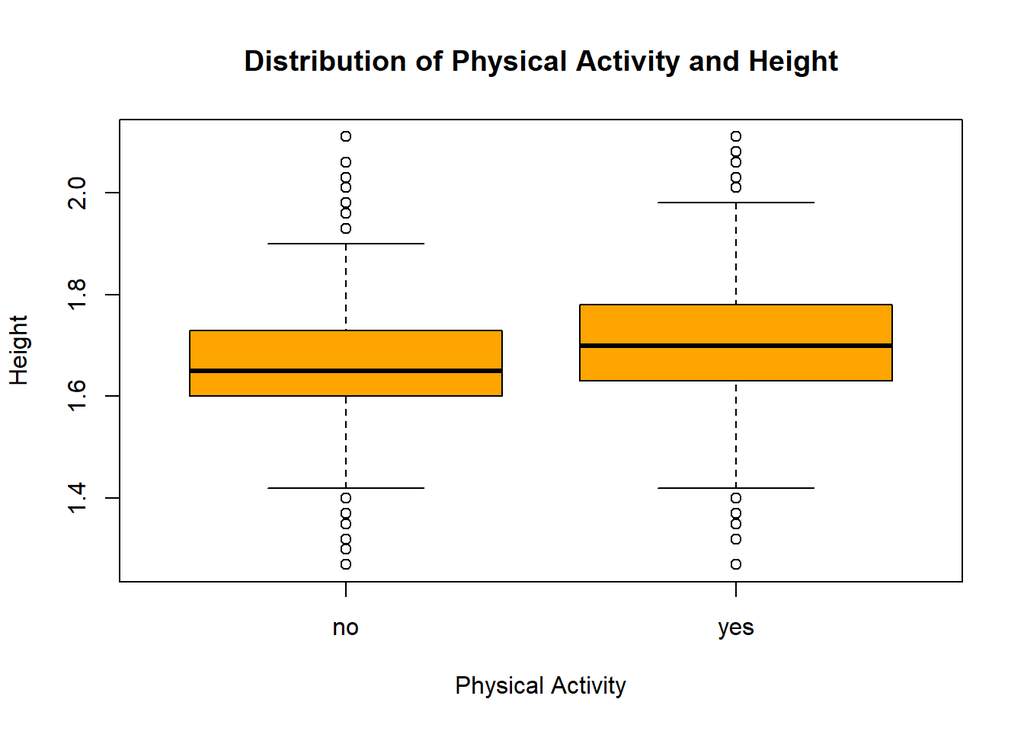

```r
boxplot(yrbss$height ~ yrbss$physical_3plus, col="orange", main="Distribution of Physical Activity and Height", ylab="Height", xlab="Physical Activity")
```

There appears to be a difference in height between the two groups.

```r
yrbss %>%
  group_by(physical_3plus) %>%
  summarise(mean_height = mean(height, na.rm = TRUE))
```

```
## # A tibble: 3 x 2
##   physical_3plus mean_height
##   <chr>                <dbl>
## 1 no                    1.67
## 2 yes                   1.70
## 3 <NA>                  1.71
```

```r
obs_diff_ht <- yrbss %>%
  specify(height ~ physical_3plus) %>%
  calculate(stat = "diff in means", order = c("yes", "no"))
null_dist_ht <- yrbss %>%
  specify(height ~ physical_3plus) %>%
  hypothesize(null = "independence") %>%
  generate(reps = 1000, type = "permute") %>%
  calculate(stat = "diff in means", order = c("yes", "no"))
```

```
## Warning: Removed 1219 rows containing missing values.
```

```r
null_dist_ht %>%
  get_p_value(obs_stat = obs_diff_ht, direction = "two_sided")
```

```
## Warning: Please be cautious in reporting a p-value of 0. This result is an
## approximation based on the number of `reps` chosen in the `generate()` step. See
## `?get_p_value()` for more information.
```

```
## # A tibble: 1 x 1
##   p_value
##     <dbl>
## 1       0
```

What this warning means is that, although the result in calculations is 0, p-value is an *approximation* and not the real zero. As the number of repetitions grow, the p-value becomes increasingly small or approaches 0.

```r
p1 <- yrbss %>%
    filter(physical_3plus == "yes") %>%
    summarise(mean_height = mean(height, na.rm = TRUE),
              total = n())
p2 <- yrbss %>%
  filter(physical_3plus == "no") %>%
    summarise(mean_height = mean(height, na.rm = TRUE),
              total = n())

n <- 12364

prop1 <- p1$total/n
prop2 <- p2$total/n

mean_diff <- p1$mean_height - p2$mean_height

se <- ( ((prop1 * (1 - prop1)) / n) +  ((prop2 * (1 - prop2)) / n)) ** 0.5
z <- 1.96

me <-z * se

ci_95 <- c(mean_diff - me, mean_diff + me)

ci_95
```

```
## [1] 0.02605665 0.04919512
```

The 95% confidence interval of the difference between those who exercise regularly and those who do not is between 0.02 and 0.05. This means that there is a difference between those who exercise and those who do not and we should reject the null hypothesis.

### Exercise 11

```r
yrbss %>%
  group_by(hours_tv_per_school_day) %>%
  summarise(n = n(), .groups="drop_last")
```

```
## # A tibble: 8 x 2
##   hours_tv_per_school_day     n
##   <chr>                   <int>
## 1 <1                       2168
## 2 1                        1750
## 3 2                        2705
## 4 3                        2139
## 5 4                        1048
## 6 5+                       1595
## 7 do not watch             1840
## 8 <NA>                      338
```

7 options, unless we count NA, then 8.

### Exercise 12

Research question: Is there evidence that students weight is affected by the sleep time?

H0: There is no relationship between weight and sleep for students. H1: There is a relationship between weight and sleep.

α Level: .05 (95% confident)

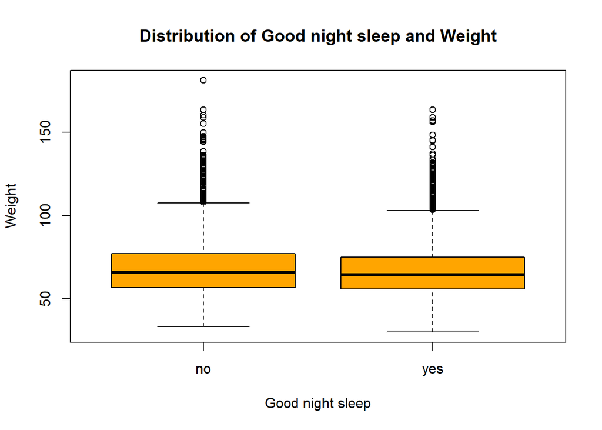

```r
yrbss <- yrbss %>%
  mutate(sleep_7plus = ifelse(yrbss$school_night_hours_sleep > 6, "yes", "no"))

boxplot(yrbss$weight ~ yrbss$sleep_7plus, col="orange", main="Distribution of Good night sleep and Weight", ylab="Weight", xlab="Good night sleep")
```

The boxplot points to a slight difference in weight.

```r
weight_no <- yrbss %>%
    filter(sleep_7plus == "no") %>%
    summarise(w_avg = mean(weight, na.rm = TRUE),
              w_sd = sd(weight, na.rm=TRUE),
              total = n())

weight_yes <- yrbss %>%
    filter(sleep_7plus == "yes") %>%
    summarise(w_avg = mean(weight, na.rm = TRUE),
              w_sd = sd(weight, na.rm=TRUE),
              total = n())

mean_diff <- weight_no$w_avg - weight_yes$w_avg

se <-
  sqrt(
  ((weight_no$w_avg**2) / weight_no$total) +
  ((weight_yes$w_avg**2) / weight_yes$total))

ci_low <- mean_diff - 1.96 * se
ci_high <- mean_diff + 1.96 * se

ci_95 <- c(ci_low, ci_high)

ci_95
```

```
## [1] -0.9169308  3.9251705
```